# ASML Project - Exercise 2 - Titanic analysis - José Lise - DSTI S19

The goal is to carry out the Titanic data classification analysis. We will use the [Titanic dataset](https://www.kaggle.com/c/titanic/data) available on [Kaggle](https://www.kaggle.com/) web site. In detail, this is a binary classification problem. The model must be able to predict survival or not with a good accuracy on the test sample.

The data has been splitted into two groups:

- training set (train.csv)
- test set (test.csv)

*The training* set will be used to build the machine learning models. For the training set, is provided the outcome (also known as the “ground truth”) for each passenger.

*The test* set will be used to see how well the models perform on unseen data. For the test set, the ground truth for each passenger is not provided. It is the models’ job to predict these outcomes. For each passenger in the test set, we will use the trained model to predict whether or not they survived the sinking of the Titanic. And as we don’t have the outcome for the test set, we will submit our prediction to the kaggle web site to get our score.

## Loading the data

```r
setwd("D:/OneDrive - Data ScienceTech Institute/DSTI/AdvanceStatisticsMachineLearning/Project")
train <- read.csv("titanic/train.csv", stringsAsFactors=FALSE, header=TRUE, sep=',')
test <-  read.csv("titanic/test.csv", stringsAsFactors=FALSE, header=TRUE, sep=',')
```

## check the train data frame

```r
str(train)
```

```
'data.frame':   891 obs. of  12 variables:
 $ PassengerId: int  1 2 3 4 5 6 7 8 9 10 ...
 $ Survived   : int  0 1 1 1 0 0 0 0 1 1 ...
 $ Pclass     : int  3 1 3 1 3 3 1 3 3 2 ...
 $ Name       : chr  "Braund, Mr. Owen Harris" "Cumings, Mrs. John Bradley (Florence Briggs Thayer)" "Heikkinen, Miss. Laina" "Futrelle, Mrs. Jacques Heath (Lily May Peel)" ...
 $ Sex        : chr  "male" "female" "female" "female" ...
 $ Age        : num  22 38 26 35 35 NA 54 2 27 14 ...
 $ SibSp      : int  1 1 0 1 0 0 0 3 0 1 ...
 $ Parch      : int  0 0 0 0 0 0 0 1 2 0 ...
 $ Ticket     : chr  "A/5 21171" "PC 17599" "STON/O2. 3101282" "113803" ...
 $ Fare       : num  7.25 71.28 7.92 53.1 8.05 ...
 $ Cabin      : chr  "" "C85" "" "C123" ...
 $ Embarked   : chr  "S" "C" "S" "S" ...
```

There are 891 observations of 12 variables. 5 variables are integers, 5 are characters and 2 are numeric.

Summary train

```r
summary(train)
```

```
  PassengerId       Survived          Pclass          Name               Sex
 Min.   :  1.0   Min.   :0.0000   Min.   :1.000   Length:891         Length:891
 1st Qu.:223.5   1st Qu.:0.0000   1st Qu.:2.000   Class :character   Class :character
 Median :446.0   Median :0.0000   Median :3.000   Mode  :character   Mode  :character
 Mean   :446.0   Mean   :0.3838   Mean   :2.309
 3rd Qu.:668.5   3rd Qu.:1.0000   3rd Qu.:3.000
 Max.   :891.0   Max.   :1.0000   Max.   :3.000

      Age            SibSp           Parch           Ticket               Fare
 Min.   : 0.42   Min.   :0.000   Min.   :0.0000   Length:891         Min.   :  0.00
 1st Qu.:20.12   1st Qu.:0.000   1st Qu.:0.0000   Class :character   1st Qu.:  7.91
 Median :28.00   Median :0.000   Median :0.0000   Mode  :character   Median : 14.45
 Mean   :29.70   Mean   :0.523   Mean   :0.3816                      Mean   : 32.20
 3rd Qu.:38.00   3rd Qu.:1.000   3rd Qu.:0.0000                      3rd Qu.: 31.00
 Max.   :80.00   Max.   :8.000   Max.   :6.0000                      Max.   :512.33
 NA's   :177
    Cabin             Embarked
 Length:891         Length:891
 Class :character   Class :character
 Mode  :character   Mode  :character
```

The summary above already shows that there are 177 missing rows for the age variable.

## Variables description

Here are the short description of the variables in the dataset:

- PassengerId: Identification number for passengers
- Survived: Indicates if the passenger survived: 0=NO, 1=YES
- Pclass: Ticket Class: 1=1st, 2=2nd, 3=3rd
- Sex: Female, Male
- Age: Age in years
- SibSp: # of sibling/Spouses abroard the Titanic
- Parch: # of Parents/Children abroad the Titanic
- Ticket: Ticket number
- fare: Passenger fare
- cabin: Cabin number
- embarked: Port of Embarkation: C=Cherburg, Q=Queenstown, S=Southampton

Here are some additionnal information for the variables: *pclass*: A proxy for socio-economic status (SES)

- 1st = Upper
- 2nd = Middle
- 3rd = Lower

*age*: Age is fractional if less than 1. If the age is estimated, is it in the form of xx.5

*sibsp*: The dataset defines family relations in this way:

- Sibling = brother, sister, stepbrother, stepsister
- Spouse = husband, wife (mistresses and fiancés were ignored)

*parch*: The dataset defines family relations in this way:

- Parent = mother, father
- Child = daughter, son, stepdaughter, stepson  
  Some children travelled only with a nanny, therefore parch=0 for them.

check the test data frame

```r
str(test)
```

```
'data.frame':   418 obs. of  11 variables:
 $ PassengerId: int  892 893 894 895 896 897 898 899 900 901 ...
 $ Pclass     : int  3 3 2 3 3 3 3 2 3 3 ...
 $ Name       : chr  "Kelly, Mr. James" "Wilkes, Mrs. James (Ellen Needs)" "Myles, Mr. Thomas Francis" "Wirz, Mr. Albert" ...
 $ Sex        : chr  "male" "female" "male" "male" ...
 $ Age        : num  34.5 47 62 27 22 14 30 26 18 21 ...
 $ SibSp      : int  0 1 0 0 1 0 0 1 0 2 ...
 $ Parch      : int  0 0 0 0 1 0 0 1 0 0 ...
 $ Ticket     : chr  "330911" "363272" "240276" "315154" ...
 $ Fare       : num  7.83 7 9.69 8.66 12.29 ...
 $ Cabin      : chr  "" "" "" "" ...
 $ Embarked   : chr  "Q" "S" "Q" "S" ...
```

Test data set contains 418 observation of 11 variables. As expected, the survived variable is missing from this data set.

Test summary

```r
summary(test)
```

```
  PassengerId         Pclass          Name               Sex                 Age
 Min.   : 892.0   Min.   :1.000   Length:418         Length:418         Min.   : 0.17
 1st Qu.: 996.2   1st Qu.:1.000   Class :character   Class :character   1st Qu.:21.00
 Median :1100.5   Median :3.000   Mode  :character   Mode  :character   Median :27.00
 Mean   :1100.5   Mean   :2.266                                         Mean   :30.27
 3rd Qu.:1204.8   3rd Qu.:3.000                                         3rd Qu.:39.00
 Max.   :1309.0   Max.   :3.000                                         Max.   :76.00
                                                                        NA's   :86
     SibSp            Parch           Ticket               Fare            Cabin
 Min.   :0.0000   Min.   :0.0000   Length:418         Min.   :  0.000   Length:418
 1st Qu.:0.0000   1st Qu.:0.0000   Class :character   1st Qu.:  7.896   Class :character
 Median :0.0000   Median :0.0000   Mode  :character   Median : 14.454   Mode  :character
 Mean   :0.4474   Mean   :0.3923                      Mean   : 35.627
 3rd Qu.:1.0000   3rd Qu.:0.0000                      3rd Qu.: 31.500
 Max.   :8.0000   Max.   :9.0000                      Max.   :512.329
                                                      NA's   :1
   Embarked
 Length:418
 Class :character
 Mode  :character
```

keep raw train, and test data sets for future use during the modeling part. However we will transform the variables Pclass, Sex and Embarked to factors.

```r
train_raw <- train
test_raw <- test

train_raw$Pclass <- factor(train_raw$Pclass)
train_raw$Sex <- factor(train_raw$Sex)
train_raw$Embarked <- factor(train_raw$Embarked, exclude="")

test_raw$Pclass <- factor(test_raw$Pclass)
test_raw$Sex <- factor(test_raw$Sex)
test_raw$Embarked <- factor(test_raw$Embarked, exclude="")

test_raw$Survived <- 0
all_raw <- rbind(train_raw,test_raw)
```

Merge train and test data set for exploratory analysis

```r
# Create a Survided column for the test dataset anf fill it with 0
test$Survived <- 0
all <- rbind(train,test)
```

## Handling Missing Data

```r
summary(all)
```

```
  PassengerId      Survived          Pclass          Name               Sex
 Min.   :   1   Min.   :0.0000   Min.   :1.000   Length:1309        Length:1309
 1st Qu.: 328   1st Qu.:0.0000   1st Qu.:2.000   Class :character   Class :character
 Median : 655   Median :0.0000   Median :3.000   Mode  :character   Mode  :character
 Mean   : 655   Mean   :0.2613   Mean   :2.295
 3rd Qu.: 982   3rd Qu.:1.0000   3rd Qu.:3.000
 Max.   :1309   Max.   :1.0000   Max.   :3.000

      Age            SibSp            Parch          Ticket               Fare
 Min.   : 0.17   Min.   :0.0000   Min.   :0.000   Length:1309        Min.   :  0.000
 1st Qu.:21.00   1st Qu.:0.0000   1st Qu.:0.000   Class :character   1st Qu.:  7.896
 Median :28.00   Median :0.0000   Median :0.000   Mode  :character   Median : 14.454
 Mean   :29.88   Mean   :0.4989   Mean   :0.385                      Mean   : 33.295
 3rd Qu.:39.00   3rd Qu.:1.0000   3rd Qu.:0.000                      3rd Qu.: 31.275
 Max.   :80.00   Max.   :8.0000   Max.   :9.000                      Max.   :512.329
 NA's   :263                                                         NA's   :1
    Cabin             Embarked
 Length:1309        Length:1309
 Class :character   Class :character
 Mode  :character   Mode  :character
```

In the cell below, we transform the Sex and Embarked variables to factors.

```r
all$Sex <- factor(all$Sex)
all$Embarked <- factor(all$Embarked, exclude="")

summary(all)
```

```
  PassengerId      Survived          Pclass          Name               Sex
 Min.   :   1   Min.   :0.0000   Min.   :1.000   Length:1309        female:466
 1st Qu.: 328   1st Qu.:0.0000   1st Qu.:2.000   Class :character   male  :843
 Median : 655   Median :0.0000   Median :3.000   Mode  :character
 Mean   : 655   Mean   :0.2613   Mean   :2.295
 3rd Qu.: 982   3rd Qu.:1.0000   3rd Qu.:3.000
 Max.   :1309   Max.   :1.0000   Max.   :3.000

      Age            SibSp            Parch          Ticket               Fare
 Min.   : 0.17   Min.   :0.0000   Min.   :0.000   Length:1309        Min.   :  0.000
 1st Qu.:21.00   1st Qu.:0.0000   1st Qu.:0.000   Class :character   1st Qu.:  7.896
 Median :28.00   Median :0.0000   Median :0.000   Mode  :character   Median : 14.454
 Mean   :29.88   Mean   :0.4989   Mean   :0.385                      Mean   : 33.295
 3rd Qu.:39.00   3rd Qu.:1.0000   3rd Qu.:0.000                      3rd Qu.: 31.275
 Max.   :80.00   Max.   :8.0000   Max.   :9.000                      Max.   :512.329
 NA's   :263                                                         NA's   :1
    Cabin           Embarked
 Length:1309        C   :270
 Class :character   Q   :123
 Mode  :character   S   :914
                    NA's:  2
```

Summary of the missing data

```r
sapply(all, function(attribute) {sum(is.na(attribute)==TRUE)/ length(attribute)
;})
```

```
 PassengerId     Survived       Pclass         Name          Sex          Age        SibSp
0.0000000000 0.0000000000 0.0000000000 0.0000000000 0.0000000000 0.2009167303 0.0000000000
       Parch       Ticket         Fare        Cabin     Embarked
0.0000000000 0.0000000000 0.0007639419 0.0000000000 0.0015278839
```

The output above shows that there are mising values for variables Age, Fare and Embarked. We addressed the missing data for Fare and Embarked in the following way:

- Assign missing Embarked data to the most counted port (‘S’).
- Replace the missing Fare data by the mean fare.

```r
all$Embarked[which(is.na(all$Embarked))] <- 'S'
all$Fare[which(is.na(all$Fare))] <- mean(all$Fare, na.rm=TRUE)

summary(all)
```

```
  PassengerId      Survived          Pclass          Name               Sex
 Min.   :   1   Min.   :0.0000   Min.   :1.000   Length:1309        female:466
 1st Qu.: 328   1st Qu.:0.0000   1st Qu.:2.000   Class :character   male  :843
 Median : 655   Median :0.0000   Median :3.000   Mode  :character
 Mean   : 655   Mean   :0.2613   Mean   :2.295
 3rd Qu.: 982   3rd Qu.:1.0000   3rd Qu.:3.000
 Max.   :1309   Max.   :1.0000   Max.   :3.000

      Age            SibSp            Parch          Ticket               Fare
 Min.   : 0.17   Min.   :0.0000   Min.   :0.000   Length:1309        Min.   :  0.000
 1st Qu.:21.00   1st Qu.:0.0000   1st Qu.:0.000   Class :character   1st Qu.:  7.896
 Median :28.00   Median :0.0000   Median :0.000   Mode  :character   Median : 14.454
 Mean   :29.88   Mean   :0.4989   Mean   :0.385                      Mean   : 33.295
 3rd Qu.:39.00   3rd Qu.:1.0000   3rd Qu.:0.000                      3rd Qu.: 31.275
 Max.   :80.00   Max.   :8.0000   Max.   :9.000                      Max.   :512.329
 NA's   :263
    Cabin           Embarked
 Length:1309        C:270
 Class :character   Q:123
 Mode  :character   S:916
```

The Cabin column data is managed as character data. However there are many empty strings. Moreover this variable doesn’t provide any relevant information. Therefore we will not use this feature for the modeling part.

```r
sum(all$Cabin == "")/nrow(all)
```

```
[1] 0.7746371
```

There are 77% of empty strings for the Cabin column.

Age Missing Data imputation

1. Check the title frequency

```r
table_words = table(unlist(strsplit(all$Name, "\\s+")))
sort(table_words [grep('\\.',names(table_words))], decreasing=TRUE)
```

```
      Mr.     Miss.      Mrs.   Master.       Dr.      Rev.      Col.    Major.     Mlle.
      757       260       197        61         8         8         4         2         2
      Ms.     Capt. Countess.      Don.     Dona. Jonkheer.        L.     Lady.      Mme.
        2         1         1         1         1         1         1         1         1
     Sir.
        1
```

2. Find missing age by title

```r
library(stringr)
tb_data = cbind(all$Age, str_match(all$Name, " [a-zA-Z]+\\."))
table(tb_data[is.na(tb_data[,1]),2])
```

```
     Dr.  Master.    Miss.      Mr.     Mrs.      Ms.
       1        8       50      176       27        1
```

3. Compute mean value by titles

```r
mean.mr = mean(all$Age[grepl(" Mr\\.", all$Name)],na.rm=TRUE)
mean.mrs = mean(all$Age[grepl(" Mrs\\.", all$Name)],na.rm=TRUE)
mean.dr = mean(all$Age[grepl(" Dr\\.", all$Name)],na.rm=TRUE)
mean.miss = mean(all$Age[grepl(" Miss\\.", all$Name)],na.rm=TRUE)
mean.master =  mean(all$Age[grepl(" Master\\.", all$Name)],na.rm=TRUE)
```

4. Apply the mean to the missing data

```r
all$Age[grepl(" Mr\\.", all$Name)
                & is.na(all$Age)] = mean.mr
all$Age[grepl(" Mrs\\.", all$Name)
                & is.na(all$Age)] = mean.mrs
all$Age[grepl(" Dr\\.", all$Name)
                & is.na(all$Age)] = mean.dr
all$Age[grepl(" Miss\\.", all$Name)
                & is.na(all$Age)] = mean.miss
all$Age[grepl(" Master\\.", all$Name)
                & is.na(all$Age)] = mean.master
# Special case for Ms. that we manage as Miss.
all$Age[grepl(" Ms\\.", all$Name)
                & is.na(all$Age)] = mean.miss
```

5. Check that there is no remaining missing age values

```r
sum(is.na(all$Age) == TRUE) /  length(all$Age)
```

```
[1] 0
```

## Data transformation

Manage class and sex as factors instead of numbers

```r
all$Pclass <- factor(all$Pclass)
all$Sex <- factor(all$Sex)
#all$Embarked <- factor(all$Embarked)
```

Add a variable title

```r
all$Title <- substring(str_extract(all$Name, '\\, \\w*\\.'), 3)
all$Title <- factor(all$Title)
#all$Title <- gsub('([[:alpha:]]*\\, )([[:alpha:]]*\\.)([[:alpha:]]*)','\\2',all$Name)

#all$Title <- str_replace(all$Name, '(\\w*)\\, (\\w*\\.)(\\w*)',REF2)
```

## Exploratory data analysis

Breakdown by gender

```r
table(all$Sex)
```

```
female   male
   466    843
```

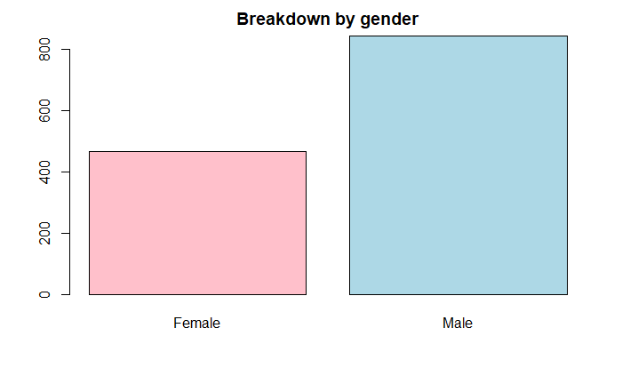

```r
barplot(table(all$Sex), names= c("Female","Male"), col= c("pink", "lightblue"), main="Breakdown by gender")
```

Breakdown by port of Embarkation

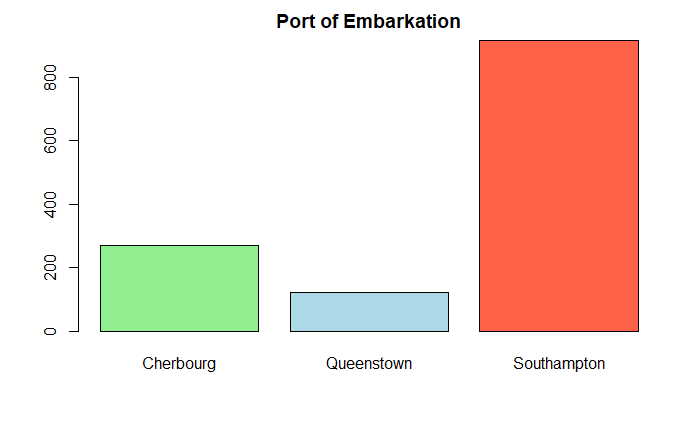

```r
barplot(table(all$Embarked), col=c("lightgreen","lightblue","tomato"), names= c("Cherbourg", "Queenstown", "Southampton"), main="Port of Embarkation")
```

Breakdown by class

```r
table(all$Pclass)
```

```
  1   2   3
323 277 709
```

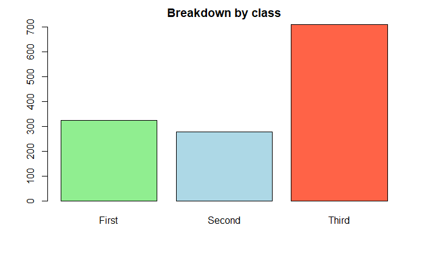

```r
barplot(table(all$Pclass), col=c("lightgreen", "lightblue", "tomato"),
        names= c("First", "Second", "Third"), main="Breakdown by class")
```

Breakdown by sex for each class

```r
table(all$Sex, all$Pclass )
```

```
           1   2   3
  female 144 106 216
  male   179 171 493
```

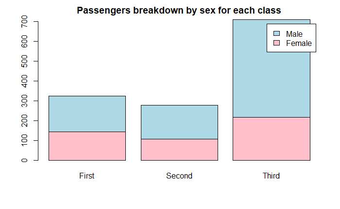

```r
countsTable <- table(all$Sex, all$Pclass )
barplot(countsTable, col=c("pink", "lightblue"), legend=c("Female", "Male"),
        names=c("First", "Second", "Third"), main="Passengers breakdown by sex for each class")
```

Hist distribution by passenger age

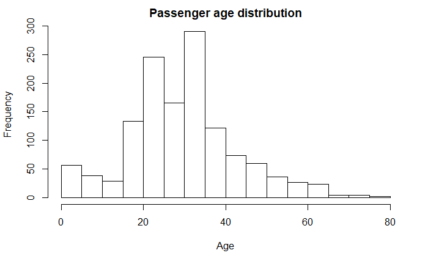

```r
hist(all$Age, main="Passenger age distribution", xlab="Age")
```

Spliting back the data in train and test sets

```r
dt <- 1:nrow(train)
train <- all[dt,]
#mrow_all <- nrow(all)
test <- all[-dt,]
test$Survived <- NULL
```

Specific Exploratory analysis of the training data set

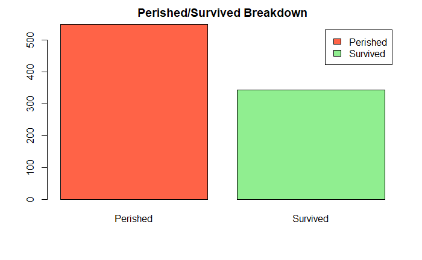

```r
barplot(table(train$Survived), col=c("Tomato", "lightgreen"),
        names=c("Perished", "Survived"), legend=c("Perished", "Survived"),
        main="Perished/Survived Breakdown" )
```

Passenger fate by age

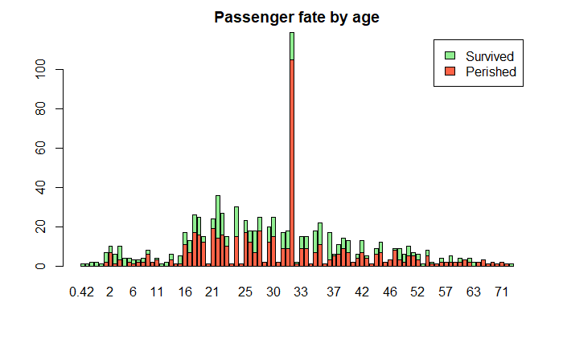

```r
barplot(table(train$Survived, train$Age), col=c("Tomato", "lightgreen"),
       legend=c("Perished", "Survived"),
        main="Passenger fate by age" )
```

Passenger fate by sex

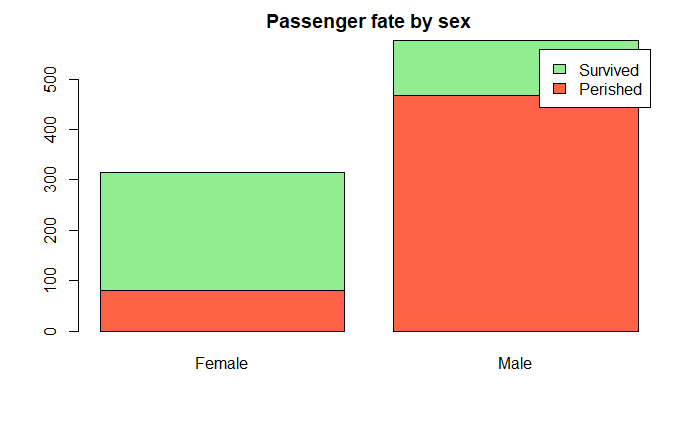

```r
barplot(table(train$Survived, train$Sex), col=c("Tomato", "lightgreen"),
       names=c("Female", "Male"), legend=c("Perished", "Survived"),
        main="Passenger fate by sex" )
```

Mosaic plot of the same data

[output not shown]

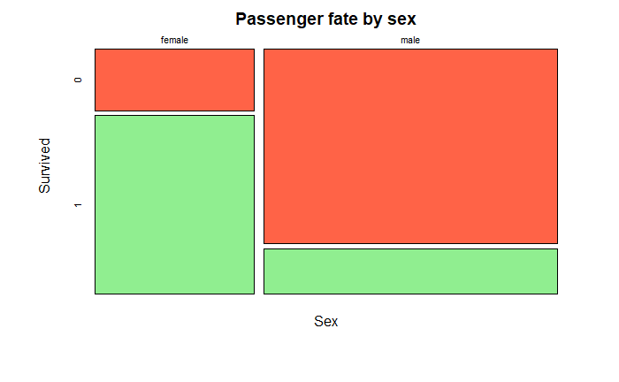

```r
mosaicplot( train$Sex~train$Survived, main="Passenger fate by sex",
            SHADE=FALSE, col=c("Tomato", "lightgreen"),xlab="Sex", ylab="Survived")
```

Passenger fate by travelling class

```r
table(train$Survived)
```

```
  0   1
549 342
```

```r
table(train$Survived, train$Pclass)
```

```
      1   2   3
  0  80  97 372
  1 136  87 119
```

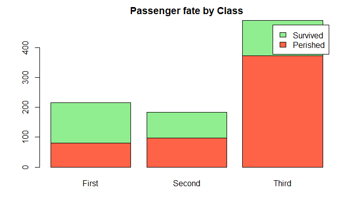

```r
barplot( table(train$Survived, train$Pclass), col=c("Tomato", "lightgreen"),
        legend = c("Perished", "Survived"), names= c("First", "Second", "Third"),
        main= "Passenger fate by Class" )
```

Corresponding Mosaic Plot

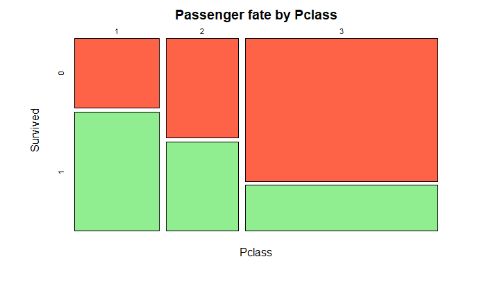

```r
mosaicplot(train$Pclass ~ train$Survived, main="Passenger fate by Pclass",
           shade=FALSE, color=c("tomato","lightgreen"), xlab="Pclass", ylab="Survived")
```

```r
NA
NA
```

## Predicting passenger survival using Decision Tree

For the modelling part, we will not take into account the following variables:

- PassengerId: This is just an identifier for the passenger and doesn’t bring any value.
- Ticket: This is just the ticket number and this doesn’t add also any value
- cabin: This is a cabin identification number that is not relevant for this analysis

```r
library(rpart)
# Step 1: Build the maximal tree

Tree <- rpart(Survived~Pclass + Sex + Age + SibSp + Parch + Fare + Embarked, data=train,
              method="class", control=rpart.control(minsplit=2,cp=0))

#Tree
```

```r
#summary(Tree)
```

Error on the maximal tree

```r
pred <- predict(Tree, type="class")
error<-  1/length(train$Survived) * sum(train$Survived != pred )
error
```

```
[1] 0.01795735
```

printcp

```r
A <- printcp(Tree)
```

```
Classification tree:
rpart(formula = Survived ~ Pclass + Sex + Age + SibSp + Parch +
    Fare + Embarked, data = train, method = "class", control = rpart.control(minsplit = 2,
    cp = 0))

Variables actually used in tree construction:
[1] Age      Embarked Fare     Parch    Pclass   Sex      SibSp

Root node error: 342/891 = 0.38384

n= 891

           CP nsplit rel error  xerror     xstd
1  0.44444444      0  1.000000 1.00000 0.042446
2  0.03070175      1  0.555556 0.55556 0.035750
3  0.01461988      5  0.432749 0.47953 0.033824
4  0.00730994      6  0.418129 0.46784 0.033501
5  0.00584795     10  0.383041 0.46784 0.033501
6  0.00487329     12  0.371345 0.45614 0.033170
7  0.00438596     22  0.312865 0.45614 0.033170
8  0.00292398     29  0.280702 0.44152 0.032745
9  0.00194932     50  0.219298 0.42398 0.032217
10 0.00167084     56  0.207602 0.44444 0.032831
11 0.00146199     65  0.190058 0.47076 0.033582
12 0.00125313    122  0.105263 0.50000 0.034372
13 0.00116959    137  0.084795 0.52339 0.034970
14 0.00109649    142  0.078947 0.52632 0.035043
15 0.00097466    153  0.064327 0.52924 0.035116
16 0.00073099    159  0.058480 0.52924 0.035116
17 0.00058480    169  0.049708 0.52924 0.035116
18 0.00000000    174  0.046784 0.53216 0.035188
```

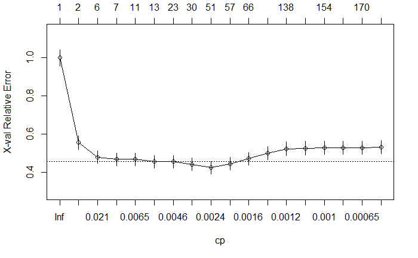

```r
plotcp(Tree)
```

Step 2: Pruning

```r
mincp <- which(A[,4] == min(A[,4]))
mincp
```

```
9
9
```

```r
#cpthres: 1-SE rule threshold : Error_min + standard_error
cpthres <- A[mincp,4] + A[mincp,5]
cp1se <- min(which(A[,4] <= cpthres))
#cp1se <- which(min(A[cand,4]) == A[,4])
cp1se
```

```
[1] 6
```

Alternative method

```r
cverr=A[,4]
mincverr=which(cverr==min(cverr))
s=A[mincverr,4]+A[mincverr,5]
s=min(s)
B=1*(cverr<=s)
a=min(which(B==1))
a
```

```
[1] 6
```

```r
cp=A[a,1]
cp
```

```
[1] 0.004873294
```

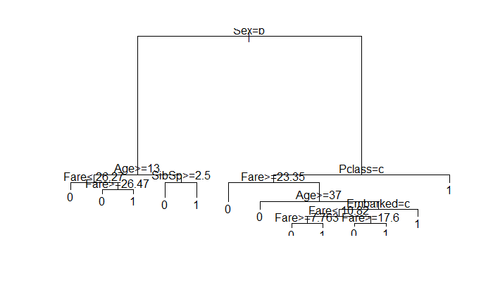

```r
#Treep <- prune(Tree, cp=A[5,1])
Treep <- prune(Tree, cp=A[cp1se,1])
plot(Treep)
text(Treep)
```

Display a more fancy plot

Install package and load library

```r
#install.packages('rattle')
#install.packages('rpart.plot')
#install.packages('RColorBrewer')
#library(rattle)
```

```r
library(rattle)
library(rpart.plot)
library(RColorBrewer)
```

Tree plot

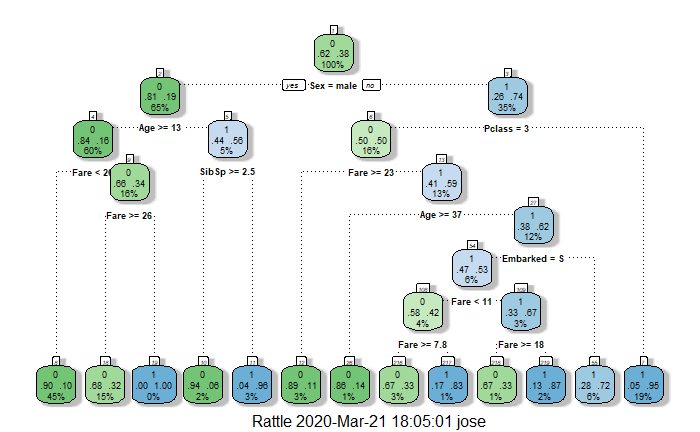

```r
fancyRpartPlot(Treep, tweak=1.4)
```

We see from the tree, that the most important variables are respectively: Sex, Age, Pclass and SibSp.

Prediction on the test set

```r
pred_dt <- predict(Treep, newdata=test, type="class")
submit_dt <- data.frame(PassengerId = test$PassengerId, Survived = pred_dt)
```

Write submission

```r
write.csv(submit_dt, file = "submit_dt_02.csv", row.names = FALSE)
```

After submission, Kaggle score is 0.79425.

## Random Forest

```r
library(randomForest)
# Set seed for reproducibility
set.seed(1234)
Tree_rf <- randomForest(as.factor(Survived) ~ Pclass + Sex + Age + SibSp + Parch +
    Fare + Embarked, data=train, importance=TRUE, proximity=TRUE, ntree=1000)

Tree_rf
```

```
Call:
 randomForest(formula = as.factor(Survived) ~ Pclass + Sex + Age +      SibSp + Parch + Fare + Embarked, data = train, importance = TRUE,      proximity = TRUE, ntree = 1000)
               Type of random forest: classification
                     Number of trees: 1000
No. of variables tried at each split: 2

        OOB estimate of  error rate: 17.28%
Confusion matrix:
    0   1 class.error
0 503  46  0.08378871
1 108 234  0.31578947
```

Prediction

```r
pred_rf <- predict(Tree_rf, newdata=test, type="class")
submit_rf <- data.frame(PassengerId = test$PassengerId, Survived = pred_rf)
```

Write submission

```r
write.csv(submit_rf, file = "submit_rf2.csv", row.names = FALSE)
```

The score for Random Forrest is 0.77990 and therefore worse that what we get for decision tree.

## Using CART without prior missing data inputation

We assume here that the train_raw data.frame is the raw data.frame with missing values:

```r
summary(train_raw)
```

```
  PassengerId       Survived      Pclass      Name               Sex
 Min.   :  1.0   Min.   :0.0000   1:216   Length:891         female:314
 1st Qu.:223.5   1st Qu.:0.0000   2:184   Class :character   male  :577
 Median :446.0   Median :0.0000   3:491   Mode  :character
 Mean   :446.0   Mean   :0.3838
 3rd Qu.:668.5   3rd Qu.:1.0000
 Max.   :891.0   Max.   :1.0000

      Age            SibSp           Parch           Ticket
 Min.   : 0.42   Min.   :0.000   Min.   :0.0000   Length:891
 1st Qu.:20.12   1st Qu.:0.000   1st Qu.:0.0000   Class :character
 Median :28.00   Median :0.000   Median :0.0000   Mode  :character
 Mean   :29.70   Mean   :0.523   Mean   :0.3816
 3rd Qu.:38.00   3rd Qu.:1.000   3rd Qu.:0.0000
 Max.   :80.00   Max.   :8.000   Max.   :6.0000
 NA's   :177
      Fare           Cabin           Embarked
 Min.   :  0.00   Length:891         C   :168
 1st Qu.:  7.91   Class :character   Q   : 77
 Median : 14.45   Mode  :character   S   :644
 Mean   : 32.20                      NA's:  2
 3rd Qu.: 31.00
 Max.   :512.33
```

We confirm that we still have missing values for Age and Embarked fields.

1. Build the maximal tree

```r
library(rpart)
# Step 1: Build the maximal tree

Tree_na <- rpart(Survived~Pclass + Sex + Age + SibSp + Parch + Fare + Embarked, data=train_raw,
              method="class", control=rpart.control(minsplit=2,cp=0))

#Tree_na
```

printcp

```r
A_na <- printcp(Tree_na)
```

```
Classification tree:
rpart(formula = Survived ~ Pclass + Sex + Age + SibSp + Parch +
    Fare + Embarked, data = train_raw, method = "class", control = rpart.control(minsplit = 2,
    cp = 0))

Variables actually used in tree construction:
[1] Age      Embarked Fare     Parch    Pclass   Sex      SibSp

Root node error: 342/891 = 0.38384

n= 891

           CP nsplit rel error  xerror     xstd
1  0.44444444      0  1.000000 1.00000 0.042446
2  0.03070175      1  0.555556 0.55556 0.035750
3  0.02339181      3  0.494152 0.50877 0.034599
4  0.02046784      4  0.470760 0.49415 0.034217
5  0.00877193      5  0.450292 0.49415 0.034217
6  0.00657895     10  0.403509 0.49708 0.034295
7  0.00584795     17  0.356725 0.50877 0.034599
8  0.00438596     18  0.350877 0.50877 0.034599
9  0.00389864     31  0.292398 0.43567 0.032571
10 0.00350877     34  0.280702 0.42690 0.032306
11 0.00292398     39  0.263158 0.43860 0.032658
12 0.00194932     68  0.178363 0.42690 0.032306
13 0.00146199     71  0.172515 0.42690 0.032306
14 0.00132908    107  0.119883 0.49123 0.034140
15 0.00116959    122  0.099415 0.51170 0.034675
16 0.00097466    136  0.078947 0.54971 0.035612
17 0.00073099    158  0.055556 0.54971 0.035612
18 0.00058480    166  0.049708 0.55848 0.035818
19 0.00000000    171  0.046784 0.56140 0.035886
```

plotcp

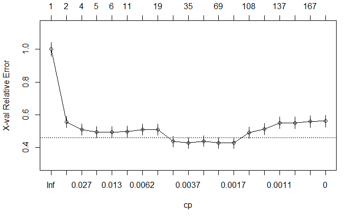

```r
plotcp(Tree_na)
```

```r
mincp <- which(A_na[,4] == min(A_na[,4]))
# as there are several min
mincps <- min(mincp)
#cpthres: 1-SE rule threshold : Error_min + standard_error
cpthres <- A_na[mincps,4] + A_na[mincps,5]
cp1se <- min(which(A_na[,4] <= cpthres))
#cp1se <- which(min(A[cand,4]) == A[,4])
cp1se
```

```
[1] 9
```

2. Pruning

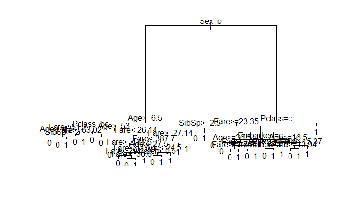

```r
Tree_nap <- prune(Tree_na, cp=A_na[cp1se,1])
plot(Tree_nap)
text(Tree_nap)
```

Fancy tree plot

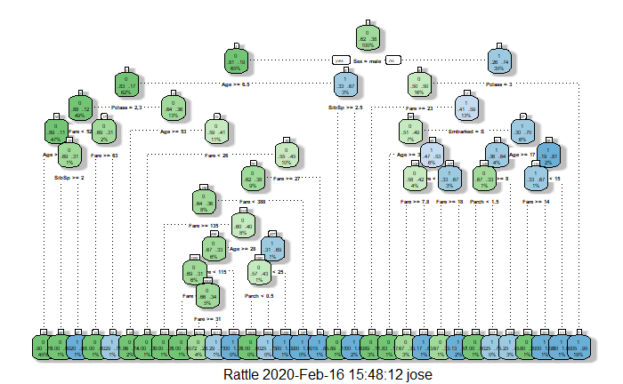

```r
fancyRpartPlot(Tree_nap, tweak=2.5)
```

Prediction on the test set

```r
pred_dt_na <- predict(Tree_nap, newdata=test_raw, type="class")
submit_dt_na <- data.frame(PassengerId = test_raw$PassengerId, Survived = pred_dt_na)
```

Write submission

```r
write.csv(submit_dt_na, file = "submit_dt_na_02.csv", row.names = FALSE)
```

After submission, Kaggle score is 0.77511. Therefore it’s worse than model with missing values inputation.

## Using CART with the additional variable title

```r
# Step 1: Build the maximal tree

Tree_title <- rpart(Survived~Pclass + Sex + Age + SibSp + Parch + Fare + Embarked + Title, data=train,
              method="class", control=rpart.control(minsplit=2,cp=0))

#Tree
```

```r
A_tl <- printcp(Tree_title)
```

```
Classification tree:
rpart(formula = Survived ~ Pclass + Sex + Age + SibSp + Parch +
    Fare + Embarked + Title, data = train, method = "class",
    control = rpart.control(minsplit = 2, cp = 0))

Variables actually used in tree construction:
[1] Age      Embarked Fare     Parch    Pclass   Sex      SibSp    Title

Root node error: 342/891 = 0.38384

n= 891

           CP nsplit rel error  xerror     xstd
1  0.46198830      0  1.000000 1.00000 0.042446
2  0.05263158      1  0.538012 0.55263 0.035681
3  0.01461988      3  0.432749 0.44737 0.032916
4  0.00974659      4  0.418129 0.47076 0.033582
5  0.00877193      7  0.388889 0.46199 0.033336
6  0.00730994      8  0.380117 0.46784 0.033501
7  0.00584795     12  0.350877 0.45322 0.033086
8  0.00438596     19  0.309942 0.46491 0.033419
9  0.00292398     21  0.301170 0.47368 0.033663
10 0.00219298     48  0.219298 0.43860 0.032658
11 0.00194932     60  0.192982 0.45906 0.033253
12 0.00167084     65  0.181287 0.47368 0.033663
13 0.00146199     75  0.163743 0.53216 0.035188
14 0.00125313    115  0.102339 0.53509 0.035260
15 0.00116959    130  0.081871 0.54386 0.035472
16 0.00109649    135  0.076023 0.54386 0.035472
17 0.00097466    146  0.061404 0.56140 0.035886
18 0.00073099    158  0.049708 0.57018 0.036088
19 0.00000000    168  0.040936 0.57018 0.036088
```

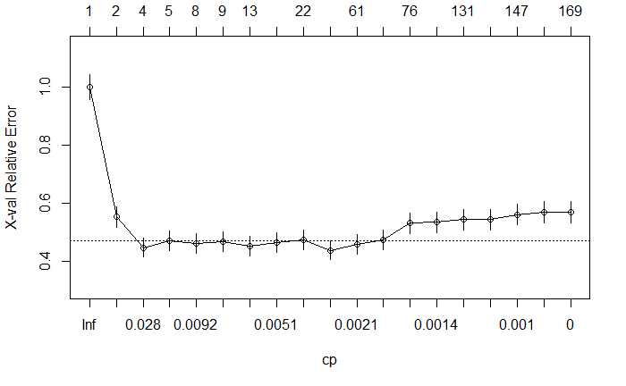

```r
plotcp(Tree_title)
```

```r
mincp <- which(A_tl[,4] == min(A_tl[,4]))
# as there are several min
mincps <- min(mincp)
#cpthres: 1-SE rule threshold : Error_min + standard_error
cpthres <- A_tl[mincps,4] + A_tl[mincps,5]
cp1se <- min(which(A_tl[,4] <= cpthres))
#cp1se <- which(min(A[cand,4]) == A[,4])
cp1se
```

```
[1] 3
```

Pruning

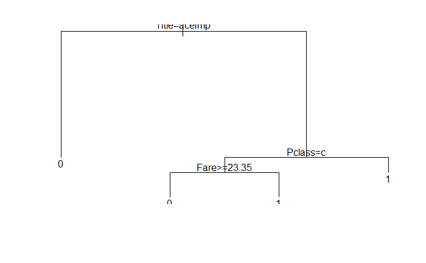

```r
Tree_tlp <- prune(Tree_title, cp=A_tl[cp1se,1])
plot(Tree_tlp)
text(Tree_tlp)
```

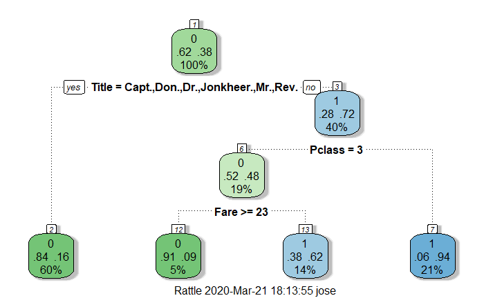

```r
fancyRpartPlot(Tree_tlp, tweak=1.0)
```

Prediction on the test set

```r
# Add an extra factor Dona. for title Dona.
#levels(train$Title) <- c(levels(train$Title), "Dona.")
pred_dt_tl <- predict(Tree_tlp, newdata=test, type="class")
submit_dt_tl <- data.frame(PassengerId = test$PassengerId, Survived = pred_dt_tl)
```

Write submission

```r
write.csv(submit_dt_tl, file = "submit_dt_tl_01.csv", row.names = FALSE)
```

After submission, Kaggle score is 0.79425

# Conclusion

We tried to predict the fate of passengers in the test set using several CART and Random Forrest models. We got the best score with the CART model with simple inputations for missing data. For this specific problem we were not able to get better results with Random Forrest models.